# **Facial Emotion Detection**

Author: Evan Sims, 19 Oct 2023

## **Problem Definition**

**The context:** Dozens of current and imagined human-computer interactions could be improved if the computer and successfully recognize human emotions by facial expression. Successful recognition of a users emotion could enable ther computer to adapt, take action, or detect a dangerous outcome, positive/negative experience, etc.  
**The objectives:** Build and train a neural net that can be images of human faces and successfully recognize the emotion displayed (one of four in this case).  
**The key questions:**

1. How to load and pre-process data?
2. What are the data like and how are they distributed?
3. Why type of model is best and what level of complexity?
4. How to augment the data and tune the hyperparameters to improve model performance?
5. How do the models perform on test data?
6. How to increase performance and speed up training?

**The problem formulation:** We are trying to build facial emotion recognition model, which is a type of computer vision. Fundamentally, it is a classification, in this case with four classes (happy, sad, surprise, and neutral).

## **About the dataset**

The data set consists of 3 folders, i.e., 'test', 'train', and 'validation'. Each of these folders has four subfolders:

**‘happy’**: Images of people who have happy facial expressions.  
**‘sad’**: Images of people with sad or upset facial expressions.  
**‘surprise’**: Images of people who have shocked or surprised facial expressions.  
**‘neutral’**: Images of people showing no prominent emotion in their facial expression at all.

## **Mounting the Drive**

**NOTE:** Please use Google Colab from your browser for this notebook. **Google.colab is NOT a library that can be downloaded locally on your device.**

```python
from google.colab import drive
drive.mount('/content/drive')
```

## **Importing the Libraries**

```python
from io import StringIO
from PIL import Image
import zipfile
import os
import pandas as pd
import matplotlib.pyplot as plt
import seaborn as sns
import numpy as np
import random

from sklearn.model_selection import train_test_split
from sklearn.preprocessing import MinMaxScaler
from sklearn.metrics import classification_report
from sklearn.metrics import confusion_matrix

from tensorflow.keras.preprocessing.image import load_img, img_to_array
from tensorflow.keras.preprocessing.image import ImageDataGenerator
from tensorflow.keras.models import Sequential
from tensorflow.keras.layers import Dense, Dropout, Activation, BatchNormalization, Conv2D, LeakyReLU, MaxPooling2D, Flatten, Input, GlobalAveragePooling2D
from tensorflow.keras.losses import categorical_crossentropy
from tensorflow.keras.optimizers import Adam, AdamW, SGD, RMSprop
from tensorflow.keras.utils import to_categorical
from tensorflow.keras import backend
from tensorflow.keras.mixed_precision import set_global_policy # may speed up model training
from tensorflow.keras import backend
import tensorflow.random as tf_random
from tensorflow.keras.callbacks import ModelCheckpoint, EarlyStopping, ReduceLROnPlateau
from tensorflow.keras.applications.vgg16 import VGG16
from tensorflow.keras import Model
```

```python
# Use an A100 GPU and invoke the mixed precision setting:

gpu_info = !nvidia-smi
gpu_info = '\n'.join(gpu_info)
if gpu_info.find('failed') >= 0:
  print('Not connected to a GPU')
else:
  print(gpu_info)
```

```
Fri Oct 20 04:19:44 2023
+-----------------------------------------------------------------------------+
| NVIDIA-SMI 525.105.17   Driver Version: 525.105.17   CUDA Version: 12.0     |
|-------------------------------+----------------------+----------------------+
| GPU  Name        Persistence-M| Bus-Id        Disp.A | Volatile Uncorr. ECC |
| Fan  Temp  Perf  Pwr:Usage/Cap|         Memory-Usage | GPU-Util  Compute M. |
|                               |                      |               MIG M. |
|===============================+======================+======================|
|   0  NVIDIA A100-SXM...  Off  | 00000000:00:04.0 Off |                    0 |
| N/A   30C    P0    42W / 400W |      0MiB / 40960MiB |      0%      Default |
|                               |                      |             Disabled |
+-------------------------------+----------------------+----------------------+

+-----------------------------------------------------------------------------+
| Processes:                                                                  |
|  GPU   GI   CI        PID   Type   Process name                  GPU Memory |
|        ID   ID                                                   Usage      |
|=============================================================================|
|  No running processes found                                                 |
+-----------------------------------------------------------------------------+
```

```python
set_global_policy('mixed_float16') # for A100 GPU
```

### **Let us load and unzip the data**

**Note:**

- You must download the dataset from the link provided on Olympus and upload the same on your Google drive before executing the code in the next cell.
- In case of any error, please make sure that the path of the file is correct as the path may be different for you.

```python
path = '/content/drive/MyDrive/MIT-ADSP/7-Capstone/'
file_zipped ='Facial_emotion_images.zip'

# Extract images from zipped file directly into the colab working directly, which temporarily saves files on the local drive of the virtual machine which contains our GPU.
# Previously, unzipped to my Drive folder then copied to the VM local disk. This direct method takes 4s vs 7min and should run each time the notebook is run:
with zipfile.ZipFile(path+file_zipped, 'r') as zipped:
    zipped.extractall('./')
```

```python
# Confirm it worked:
! ls
```

```
drive  Facial_emotion_images  sample_data
```

```python
path = "/content/"
```

```python
# Check for any bad image:

folder = 'Facial_emotion_images/'
imgs_path = path + folder

for root, dirs, files in os.walk(imgs_path):
    for file in files:
        file_path = os.path.join(root, file)
        try:
            with Image.open(file_path) as img:
                img.verify()  # This checks if it's an actual image and can be opened
        except (IOError, SyntaxError) as e:
            print('Bad file:', file_path)
```

**Observations on the data:**

The dataset consists of tiny square grayscale images of peoples faces pre-labeled as either exhibiting the emotion of either happy, neutral, sad, or surprise (as indicated by their containing folder).

The images are 48x48 pixels, meaning our input layer will have 2304 neurons (grayscale) or 6912 (rgb). Likewise, our output layer will have four neurons, representing the four classes of the dataset (happy, neutral, sad, or surprise).

The dataset comprises a zipped file with the following architecture, where each sub-sub folder contains the actual .JPG image files:

Facial_emotion_images

- test
  - happy
  - neutral
  - sad
  - surprise
- train
  - happy
  - neutral
  - sad
  - surprise
- validation
  - happy
  - neutral
  - sad
  - surprise

## **Visualizing our Classes**

Let's look at our classes.

**Write down your observation for each class. What do you think can be a unique feature of each emotion, that separates it from the remaining classes?**

```python
def display_imgs(folder_path, num_imgs=10):

    img_files = [f for f in os.listdir(folder_path) if f.endswith('.jpg')]

    plt.figure(figsize=(15, num_imgs * 15))

    for i, image_file in enumerate(img_files[:num_imgs]):
        img_path = os.path.join(folder_path, image_file)
        img = Image.open(img_path)
        plt.subplot(1, num_imgs, i+1)
        plt.imshow(img, cmap='gray')
        plt.axis('off')
    plt.show()
```

Observations and insights for all classes are provided at the end of the display sections as they are highly interrelated.

### **Happy**

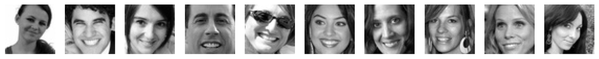

```python
emotion = 'happy'
folder_path = 'Facial_emotion_images/train/'
full_path = path + folder_path + emotion
full_path

display_imgs(full_path)
```

### **Sad**

[figure not shown]

```python
emotion = 'sad'
folder_path = 'Facial_emotion_images/train/'
full_path = path + folder_path + emotion
full_path

display_imgs(full_path)
```

### **Neutral**

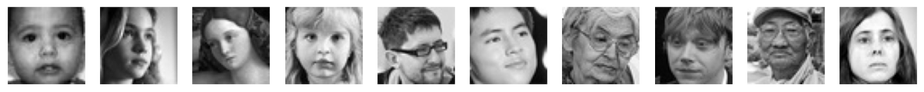

```python
emotion = 'neutral'
folder_path = 'Facial_emotion_images/train/'
full_path = path + folder_path + emotion
full_path

display_imgs(full_path)
```

### **Surprised**

[figure not shown]

```python
emotion = 'surprise'
folder_path = 'Facial_emotion_images/train/'
full_path = path + folder_path + emotion
full_path

display_imgs(full_path)
```

**Observations and Insights:**

In addition to the visualization here, it's fairly quick to manually inspect several hundred images from the classes to get a better feel for their character. A couple salient features are worth mentioning. While some images are aggressively cropped, in almost all cases the persons eyes and mouth are visible, which intuitively are the primary means by which human faces display emotion. One exception is that a few people are wearing sunglasses.

Some specifics on the individual emotions:

- Happy: Happy faces are defined most clearly by the mouth, which is smiling or grinning and often displaying teeth. The eyes and eyebrows are in a variety of positions but are almost never deeply furrowed or downturned. There is significant engagement of the facial musculature.
- Sad: Sad faces usually have downturned (ie frowning) or tightly pursed lips, eyes are often downturned and brows furrowed, but here there is a wide variety, too. Eyes are almost never widely open. Like happiness, the facial muscles are significantly engaged
- Neutral: Neutral faces are ... neutral. The mouth and eyes are appear horizontal as compared the the other intense emotions. The mouth is closed or very slightly opened. The eyes are at an average degree of openness. The facial muscles are relaxed.
- Surprise: Surprise is clearly defined by wide open or "O" shaped mouth and wide open eyes, often with hands on the mouth or cheeks.

The cohort that these images represent spans a wide array of races and ages, from infants to elderly. It even includes an image of George W Bush with a look of surprise. So we can hypothesize that a good generalizable deep learning model could work for images of people anywhere in the world and of any age, including former politicians.

We can also attempt to anticipate some difficulties that a model may have learning from these images. Many of the happy faces could be confused for surprised ones and vice versa. Likewise with neutral and sad. Many of the "neutral" faces also contain a wide variety of distinctively non-neutral expressions, such as boredom, frustration, sleepiness, weariness, and others. So we should bear these facts in mind when it comes to classification results and their limitations.

## **Checking Distribution of Classes**

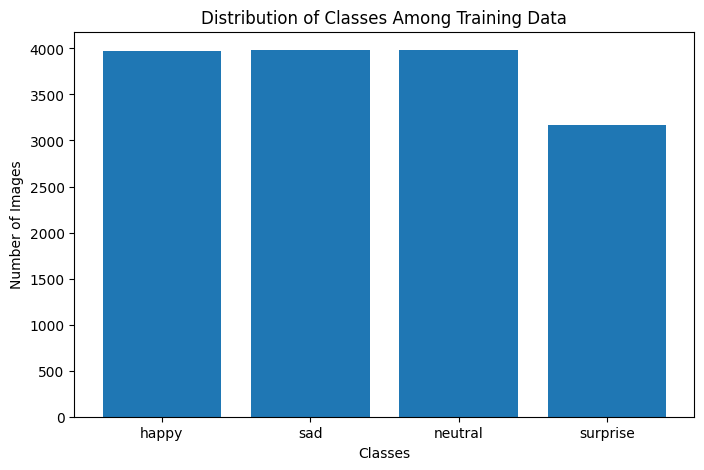

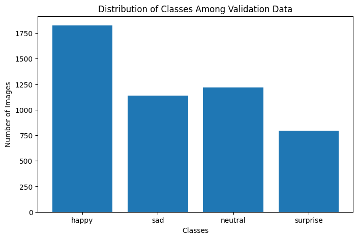

```python
train_path = path + 'Facial_emotion_images/train'

classes = ['happy', 'sad', 'neutral', 'surprise']

class_counts = {}

for cls in classes:
    cls_path = os.path.join(train_path, cls)
    class_counts[cls] = len([f for f in os.listdir(cls_path) if f.endswith('.jpg')])

labels = list(class_counts.keys())
counts = list(class_counts.values())

plt.figure(figsize=(8, 5))
plt.bar(labels, counts)
plt.xlabel('Classes')
plt.ylabel('Number of Images')
plt.title('Distribution of Classes Among Training Data')
plt.show()


val_path = path + 'Facial_emotion_images/validation'

classes = ['happy', 'sad', 'neutral', 'surprise']

class_counts = {}

for cls in classes:
    cls_path = os.path.join(val_path, cls)
    class_counts[cls] = len([f for f in os.listdir(cls_path) if f.endswith('.jpg')])

labels = list(class_counts.keys())
counts = list(class_counts.values())

plt.figure(figsize=(8, 5))
plt.bar(labels, counts)
plt.xlabel('Classes')
plt.ylabel('Number of Images')
plt.title('Distribution of Classes Among Validation Data')
plt.show()
```

**Observations and Insights:**

For the training data, there is a fairly even distribution among all classes. There's a bit fewer images showing surprise but likely not enough to matter.

For the validation data, there is an overrepresentation of happy and dearth of surprise. Based on how training and test results have gone, it doesn't seem to be a big enough difference to matter.

**Think About It:**

- Are the classes equally distributed? If not, do you think the imbalance is too high? Will it be a problem as we progress?
- Are there any Exploratory Data Analysis tasks that we can do here? Would they provide any meaningful insights?

## **Creating our Data Loaders**

In this section, we are creating data loaders that we will use as inputs to our Neural Network.

**You have two options for the color_mode. You can set it to color_mode = 'rgb' or color_mode = 'grayscale'. You will need to try out both and see for yourself which one gives better performance.**

```python
from sklearn.utils import shuffle
batch_size  = 32
img_size = 48 # height and width the same. Change to 224x224 for Transfer Learning models later.

train_path = path + 'Facial_emotion_images/train'
validation_path = path + 'Facial_emotion_images/validation'
test_path = path + 'Facial_emotion_images/test'

train_datagen = ImageDataGenerator(
    rescale=1./255,
    brightness_range=(0.,2.),
    shear_range=0.25,
    horizontal_flip=True,
)

validation_datagen = ImageDataGenerator(rescale=1./255)

test_datagen = ImageDataGenerator(rescale=1. / 255)

# Load images as both grayscale and rbg

color_mode = 'grayscale'

train_data_g = train_datagen.flow_from_directory(
    train_path,
    target_size=(img_size, img_size),
    batch_size=batch_size,
    class_mode='categorical',
    color_mode=color_mode
)

validation_data_g = validation_datagen.flow_from_directory(
    validation_path,
    target_size=(img_size, img_size),
    batch_size=batch_size,
    class_mode='categorical',
    color_mode=color_mode
)

test_data_g = test_datagen.flow_from_directory(
     test_path,
     target_size=(img_size, img_size),
     batch_size=batch_size,
     class_mode='categorical',
     color_mode=color_mode,
     shuffle=False
)


color_mode = 'rgb'

train_data_rgb = train_datagen.flow_from_directory(
    train_path,
    target_size=(img_size, img_size),
    batch_size=batch_size,
    class_mode='categorical',
    color_mode=color_mode
)

validation_data_rgb = validation_datagen.flow_from_directory(
    validation_path,
    target_size=(img_size, img_size),
    batch_size=batch_size,
    class_mode='categorical',
    color_mode=color_mode
)

test_data_rgb = test_datagen.flow_from_directory(
     test_path,
     target_size=(img_size, img_size),
     batch_size=batch_size,
     class_mode='categorical',
     color_mode=color_mode,
     shuffle=False
)
```

```
Found 15109 images belonging to 4 classes.
Found 4977 images belonging to 4 classes.
Found 128 images belonging to 4 classes.
Found 15109 images belonging to 4 classes.
Found 4977 images belonging to 4 classes.
Found 128 images belonging to 4 classes.
```

**Comments:**

Validation data: 4977 images

Test data: 128 images

## **Functions for Reused Code**

```python
import matplotlib.pyplot as plt

def training_performance_plots(model_name, history):

    #model_name (str)
    if type(history) == dict:
      acc = history['accuracy']
      val_acc = history['val_accuracy']
      loss = history['loss']
      val_loss = history['val_loss']

    else:
      acc = history.history['accuracy']
      val_acc = history.history['val_accuracy']
      loss = history.history['loss']
      val_loss = history.history['val_loss']

    fig, (ax1, ax2) = plt.subplots(1, 2, figsize=(12, 6))
    fig.suptitle(f"Model Training Performance: {model_name}")

    ax1.plot(range(1, len(acc) + 1), acc)
    ax1.plot(range(1, len(val_acc) + 1), val_acc)
    ax1.set_title('History of Accuracy')
    ax1.set_xlabel('Epochs')
    ax1.set_ylabel('Accuracy')
    ax1.legend(['training', 'validation'])

    ax2.plot(range(1, len(loss) + 1), loss)
    ax2.plot(range(1, len(val_loss) + 1), val_loss)
    ax2.set_title('History of Loss')
    ax2.set_xlabel('Epochs')
    ax2.set_ylabel('Loss')
    ax2.legend(['training', 'validation'])

    plt.show()


def predict_and_report(model, test_data):

  predict = model.predict(test_data, steps=test_data.samples/test_data.batch_size)

  predict_labels = np.argmax(predict, axis = 1)

  y_test = test_data.classes

  accuracy = np.sum(predict_labels == y_test) / len(y_test)

  print(f"Test accuracy: {accuracy}")

  report = classification_report(y_test, predict_labels, target_names=test_data.class_indices.keys())
  print('\nClassification Report:\n')
  print(report)

  print('\nConfusion Matrix:')

  cm = confusion_matrix(y_test, predict_labels)

  plt.figure(figsize=(5, 4))
  sns.heatmap(cm, annot=True, fmt='d', cmap='Blues',
              xticklabels=test_data.class_indices,
              yticklabels=test_data.class_indices)
  plt.ylabel('True label')
  plt.xlabel('Predicted label')
  plt.show()
```

## **Model Building**

**Think About It:**

- Are Convolutional Neural Networks the right approach? Should we have gone with Artificial Neural Networks instead?
- What are the advantages of CNNs over ANNs and are they applicable here?

Convolutional Neural Networks (CNNs) are a specialized class of neural net that are meant for processing images or other data with a grid-like structure. They are considered the state of the art for image recognition.

As key feature of CNNs is that neurons in the convolution layer are connected to only a small subset of neurons in the input layer, allowing the model to detect local patterns. For this and other reasons, and the fact CNNs are well established to be superior for image recognition make the choice a simple one.

### **Creating the Base Neural Network**

```python
# Usual preliminaries:

backend.clear_session()
seed = 10
np.random.seed(seed)
random.seed(seed)
tf_random.set_seed(seed)
```

```python
model1_g = Sequential()

model1_g.add(Conv2D(64, kernel_size=(2, 2), activation='relu', padding='same', input_shape=(48, 48, 1)))  # Final value for input share =1 signifies grayscale
model1_g.add(MaxPooling2D(pool_size=(2, 2)))
model1_g.add(Dropout(0.2))

model1_g.add(Conv2D(32, kernel_size=(2, 2), activation='relu', padding='same'))
model1_g.add(MaxPooling2D(pool_size=(2, 2)))
model1_g.add(Dropout(0.2))

model1_g.add(Conv2D(32, kernel_size=(2, 2), activation='relu', padding='same'))
model1_g.add(MaxPooling2D(pool_size=(2, 2)))
model1_g.add(Dropout(0.2))

model1_g.add(Flatten())
model1_g.add(Dense(512, activation='relu'))
model1_g.add(Dropout(0.4))
model1_g.add(Dense(4, activation='softmax'))

model1_g.summary()
```

```
Model: "sequential"
_________________________________________________________________
 Layer (type)                Output Shape              Param #
=================================================================
 conv2d (Conv2D)             (None, 48, 48, 64)        320

 max_pooling2d (MaxPooling2  (None, 24, 24, 64)        0
 D)

 dropout (Dropout)           (None, 24, 24, 64)        0

 conv2d_1 (Conv2D)           (None, 24, 24, 32)        8224

 max_pooling2d_1 (MaxPoolin  (None, 12, 12, 32)        0
 g2D)

 dropout_1 (Dropout)         (None, 12, 12, 32)        0

 conv2d_2 (Conv2D)           (None, 12, 12, 32)        4128

 max_pooling2d_2 (MaxPoolin  (None, 6, 6, 32)          0
 g2D)

 dropout_2 (Dropout)         (None, 6, 6, 32)          0

 flatten (Flatten)           (None, 1152)              0

 dense (Dense)               (None, 512)               590336

 dropout_3 (Dropout)         (None, 512)               0

 dense_1 (Dense)             (None, 4)                 2052

=================================================================
Total params: 605060 (2.31 MB)
Trainable params: 605060 (2.31 MB)
Non-trainable params: 0 (0.00 Byte)
_________________________________________________________________
```

### **Compiling and Training the Model**

```python
model1_g.compile(optimizer='adam', loss='categorical_crossentropy', metrics=['accuracy'])

checkpoint = ModelCheckpoint("model1_g.h5",
                             monitor='val_acc',
                             mode='max',
                             save_best_only=True,
                             verbose=1)

# EarlyStopping
earlystop = EarlyStopping(monitor='val_loss',
                          min_delta=0,
                          patience=3,
                          verbose=1,
                          restore_best_weights=True)

# ReduceLROnPlateau
reduce_lr = ReduceLROnPlateau(monitor='val_loss',
                              factor=0.2,
                              patience=3,
                              verbose=1,
                              min_delta=0.0001)

callbacks = [checkpoint, earlystop, reduce_lr]
```

```python
history_1g = model1_g.fit(
    train_data_g,
    epochs=20,
    validation_data=validation_data_g,
    callbacks=callbacks
)
```

[output not shown]

[output not shown]

[output not shown]

[output not shown]

[output not shown]

[output not shown]

[output not shown]

[output not shown]

[output not shown]

[output not shown]

[output not shown]

[output not shown]

[output not shown]

[output not shown]

[output not shown]

[output not shown]

[output not shown]

[output not shown]

[output not shown]

[output not shown]

```
Restoring model weights from the end of the best epoch: 17.

Epoch 20: ReduceLROnPlateau reducing learning rate to 0.00020000000949949026.
Epoch 20: early stopping
```

```python
# Save the model:

model_path1 = "/content/drive/MyDrive/MIT-ADSP/7-Capstone/model1_g.h5"
model_path2 = "/content/drive/MyDrive/MIT-ADSP/7-Capstone/model1_g.keras"
model1_g.save(model_path1)
model1_g.save(model_path2)
```

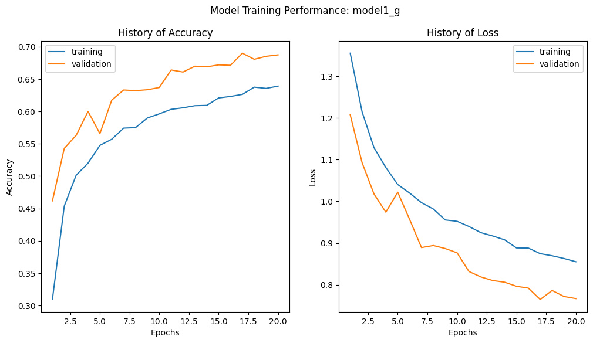

```python
training_performance_plots('model1_g', history_1g)
```

### **Evaluating the Model on the Test Set**

```python
# Load model if needed:
# model1_g.load_weights('./model1_g.h5')
```

```
Test accuracy: 0.625

Classification Report:

              precision    recall  f1-score   support

       happy       0.68      0.72      0.70        32
     neutral       0.52      0.69      0.59        32
         sad       0.38      0.31      0.34        32
    surprise       0.96      0.78      0.86        32

    accuracy                           0.62       128
   macro avg       0.64      0.62      0.62       128
weighted avg       0.64      0.62      0.62       128


Confusion Matrix:
```

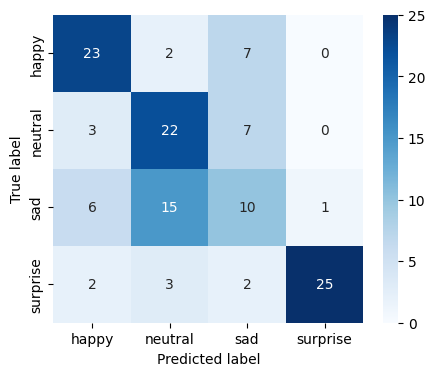

```python
predict_and_report(model1_g, test_data_g)
```

**Observations and Insights:**

### **Creating the second Convolutional Neural Network**

- Try out a slightly larger architecture

```python
backend.clear_session()
seed = 10
np.random.seed(seed)
random.seed(seed)
tf_random.set_seed(seed)
```

```python
model2_g = Sequential()

model2_g.add(Conv2D(256, kernel_size=2, padding='same', input_shape=(48, 48, 1)))  # grayscale images
model2_g.add(BatchNormalization())
model2_g.add(LeakyReLU(alpha=0.1))
model2_g.add(MaxPooling2D(pool_size=2))

model2_g.add(Conv2D(128, kernel_size=2, padding='same'))
model2_g.add(BatchNormalization())
model2_g.add(LeakyReLU(alpha=0.1))
model2_g.add(MaxPooling2D(pool_size=2))

model2_g.add(Conv2D(64, kernel_size=2, padding='same'))
model2_g.add(BatchNormalization())
model2_g.add(LeakyReLU(alpha=0.1))
model2_g.add(MaxPooling2D(pool_size=2))

model2_g.add(Conv2D(32, kernel_size=2, padding='same'))
model2_g.add(BatchNormalization())
model2_g.add(LeakyReLU(alpha=0.1))
model2_g.add(MaxPooling2D(pool_size=2))

model2_g.add(Flatten())
model2_g.add(Dense(512, activation='relu'))
model2_g.add(Dense(128, activation='relu'))
model2_g.add(Dense(4, activation='softmax'))

model2_g.summary()
```

```
Model: "sequential"
_________________________________________________________________
 Layer (type)                Output Shape              Param #
=================================================================
 conv2d (Conv2D)             (None, 48, 48, 256)       1280

 batch_normalization (Batch  (None, 48, 48, 256)       1024
 Normalization)

 leaky_re_lu (LeakyReLU)     (None, 48, 48, 256)       0

 max_pooling2d (MaxPooling2  (None, 24, 24, 256)       0
 D)

 conv2d_1 (Conv2D)           (None, 24, 24, 128)       131200

 batch_normalization_1 (Bat  (None, 24, 24, 128)       512
 chNormalization)

 leaky_re_lu_1 (LeakyReLU)   (None, 24, 24, 128)       0

 max_pooling2d_1 (MaxPoolin  (None, 12, 12, 128)       0
 g2D)

 conv2d_2 (Conv2D)           (None, 12, 12, 64)        32832

 batch_normalization_2 (Bat  (None, 12, 12, 64)        256
 chNormalization)

 leaky_re_lu_2 (LeakyReLU)   (None, 12, 12, 64)        0

 max_pooling2d_2 (MaxPoolin  (None, 6, 6, 64)          0
 g2D)

 conv2d_3 (Conv2D)           (None, 6, 6, 32)          8224

 batch_normalization_3 (Bat  (None, 6, 6, 32)          128
 chNormalization)

 leaky_re_lu_3 (LeakyReLU)   (None, 6, 6, 32)          0

 max_pooling2d_3 (MaxPoolin  (None, 3, 3, 32)          0
 g2D)

 flatten (Flatten)           (None, 288)               0

 dense (Dense)               (None, 512)               147968

 dense_1 (Dense)             (None, 128)               65664

 dense_2 (Dense)             (None, 4)                 516

=================================================================
Total params: 389604 (1.49 MB)
Trainable params: 388644 (1.48 MB)
Non-trainable params: 960 (3.75 KB)
_________________________________________________________________
```

### **Compiling and Training the Model**

```python
model2_g.compile(optimizer='adam', loss='categorical_crossentropy', metrics=['accuracy'])

checkpoint = ModelCheckpoint("model2_g.h5",
                             monitor='val_acc',
                             mode='max',
                             save_best_only=True,
                             verbose=1)

# EarlyStopping
earlystop = EarlyStopping(monitor='val_loss',
                          min_delta=0,
                          patience=3,
                          verbose=1,
                          restore_best_weights=True)

# ReduceLROnPlateau
reduce_lr = ReduceLROnPlateau(monitor='val_loss',
                              factor=0.2,
                              patience=3,
                              verbose=1,
                              min_delta=0.0001)

callbacks = [checkpoint, earlystop, reduce_lr]
```

```python
history_2g = model2_g.fit(
    train_data_g,
    epochs=20,
    validation_data=validation_data_g,
    callbacks=callbacks
)
```

[output not shown]

[output not shown]

[output not shown]

[output not shown]

[output not shown]

[output not shown]

[output not shown]

[output not shown]

[output not shown]

[output not shown]

[output not shown]

[output not shown]

[output not shown]

[output not shown]

[output not shown]

```
Restoring model weights from the end of the best epoch: 12.

Epoch 15: ReduceLROnPlateau reducing learning rate to 0.00020000000949949026.
Epoch 15: early stopping
```

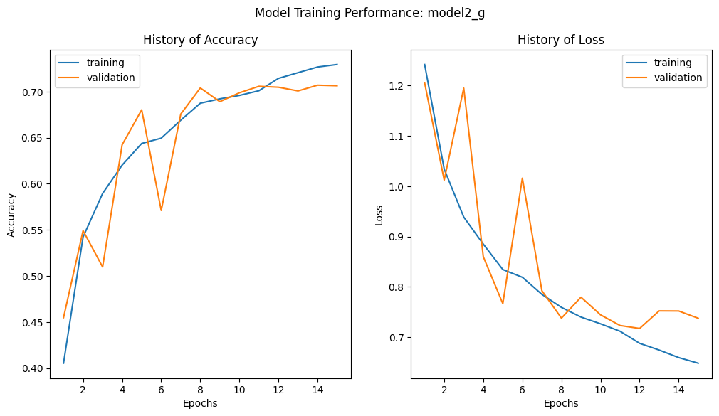

```python
training_performance_plots('model2_g', history_2g)
```

```python
model_path1 = "/content/drive/MyDrive/MIT-ADSP/7-Capstone/model2_g.h5"
model_path2 = "/content/drive/MyDrive/MIT-ADSP/7-Capstone/model2_g.keras"
model2_g.save(model_path1)
model2_g.save(model_path2)
```

### **Evaluating the Model on the Test Set**

```
Test accuracy: 0.703125

Classification Report:

              precision    recall  f1-score   support

       happy       0.67      0.88      0.76        32
     neutral       0.69      0.69      0.69        32
         sad       0.58      0.56      0.57        32
    surprise       0.96      0.69      0.80        32

    accuracy                           0.70       128
   macro avg       0.72      0.70      0.70       128
weighted avg       0.72      0.70      0.70       128


Confusion Matrix:
```

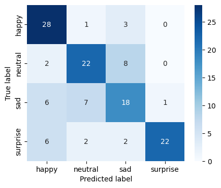

```python
predict_and_report(model2_g,test_data_g)
```

**Observations and Insights:**

The 2nd CNN achieves a validation accuracy of 0.7064 and a test accuracy of 0.7031. Essentially the same confusion dynamics as the first model.

### **Creating the second Convolutional Neural Network using RGB Input**

```python
backend.clear_session()
seed = 10
np.random.seed(seed)
random.seed(seed)
tf_random.set_seed(seed)
```

```python
model2_rgb = Sequential()

model2_rgb.add(Conv2D(256, kernel_size=2, padding='same', input_shape=(48, 48, 3)))  # rgb images
model2_rgb.add(BatchNormalization())
model2_rgb.add(LeakyReLU(alpha=0.1))
model2_rgb.add(MaxPooling2D(pool_size=2))

model2_rgb.add(Conv2D(128, kernel_size=2, padding='same'))
model2_rgb.add(BatchNormalization())
model2_rgb.add(LeakyReLU(alpha=0.1))
model2_rgb.add(MaxPooling2D(pool_size=2))

model2_rgb.add(Conv2D(64, kernel_size=2, padding='same'))
model2_rgb.add(BatchNormalization())
model2_rgb.add(LeakyReLU(alpha=0.1))
model2_rgb.add(MaxPooling2D(pool_size=2))

model2_rgb.add(Conv2D(32, kernel_size=2, padding='same'))
model2_rgb.add(BatchNormalization())
model2_rgb.add(LeakyReLU(alpha=0.1))
model2_rgb.add(MaxPooling2D(pool_size=2))

model2_rgb.add(Flatten())
model2_rgb.add(Dense(512, activation='relu'))
model2_rgb.add(Dense(128, activation='relu'))
model2_rgb.add(Dense(4, activation='softmax'))

model2_rgb.summary()
```

```
Model: "sequential"
_________________________________________________________________
 Layer (type)                Output Shape              Param #
=================================================================
 conv2d (Conv2D)             (None, 48, 48, 256)       3328

 batch_normalization (Batch  (None, 48, 48, 256)       1024
 Normalization)

 leaky_re_lu (LeakyReLU)     (None, 48, 48, 256)       0

 max_pooling2d (MaxPooling2  (None, 24, 24, 256)       0
 D)

 conv2d_1 (Conv2D)           (None, 24, 24, 128)       131200

 batch_normalization_1 (Bat  (None, 24, 24, 128)       512
 chNormalization)

 leaky_re_lu_1 (LeakyReLU)   (None, 24, 24, 128)       0

 max_pooling2d_1 (MaxPoolin  (None, 12, 12, 128)       0
 g2D)

 conv2d_2 (Conv2D)           (None, 12, 12, 64)        32832

 batch_normalization_2 (Bat  (None, 12, 12, 64)        256
 chNormalization)

 leaky_re_lu_2 (LeakyReLU)   (None, 12, 12, 64)        0

 max_pooling2d_2 (MaxPoolin  (None, 6, 6, 64)          0
 g2D)

 conv2d_3 (Conv2D)           (None, 6, 6, 32)          8224

 batch_normalization_3 (Bat  (None, 6, 6, 32)          128
 chNormalization)

 leaky_re_lu_3 (LeakyReLU)   (None, 6, 6, 32)          0

 max_pooling2d_3 (MaxPoolin  (None, 3, 3, 32)          0
 g2D)

 flatten (Flatten)           (None, 288)               0

 dense (Dense)               (None, 512)               147968

 dense_1 (Dense)             (None, 128)               65664

 dense_2 (Dense)             (None, 4)                 516

=================================================================
Total params: 391652 (1.49 MB)
Trainable params: 390692 (1.49 MB)
Non-trainable params: 960 (3.75 KB)
_________________________________________________________________
```

```python
model2_rgb.compile(optimizer='adam', loss='categorical_crossentropy', metrics=['accuracy'])

checkpoint = ModelCheckpoint("model2_rgb.h5",
                             monitor='val_acc',
                             mode='max',
                             save_best_only=True,
                             verbose=1)

# EarlyStopping
earlystop = EarlyStopping(monitor='val_loss',
                          min_delta=0,
                          patience=3,
                          verbose=1,
                          restore_best_weights=True)

# ReduceLROnPlateau
reduce_lr = ReduceLROnPlateau(monitor='val_loss',
                              factor=0.2,
                              patience=3,
                              verbose=1,
                              min_delta=0.0001)

callbacks = [checkpoint, earlystop, reduce_lr]
```

```python
history_2rgb = model2_rgb.fit(
    train_data_rgb,
    epochs=20,
    validation_data=validation_data_rgb,
    callbacks=callbacks
)
```

[output not shown]

[output not shown]

[output not shown]

[output not shown]

[output not shown]

[output not shown]

[output not shown]

[output not shown]

[output not shown]

[output not shown]

[output not shown]

[output not shown]

[output not shown]

[output not shown]

[output not shown]

```
Restoring model weights from the end of the best epoch: 12.

Epoch 15: ReduceLROnPlateau reducing learning rate to 0.00020000000949949026.
Epoch 15: early stopping
```

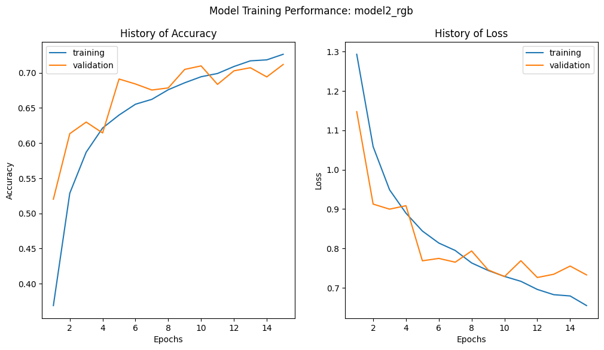

```python
training_performance_plots('model2_rgb', history_2rgb)
```

```python
model_path1 = "/content/drive/MyDrive/MIT-ADSP/7-Capstone/model2_rgb.h5"
model_path2 = "/content/drive/MyDrive/MIT-ADSP/7-Capstone/model2_rgb.keras"
model2_rgb.save(model_path1)
model2_rgb.save(model_path2)
```

```
Test accuracy: 0.7578125

Classification Report:

              precision    recall  f1-score   support

       happy       0.78      0.88      0.82        32
     neutral       0.77      0.53      0.63        32
         sad       0.62      0.81      0.70        32
    surprise       0.93      0.81      0.87        32

    accuracy                           0.76       128
   macro avg       0.77      0.76      0.76       128
weighted avg       0.77      0.76      0.76       128


Confusion Matrix:
```

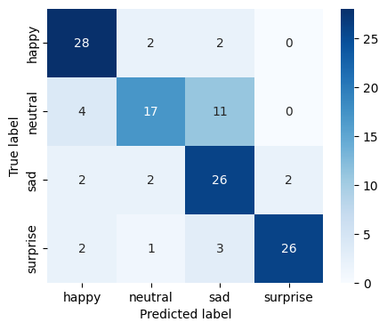

```python
predict_and_report(model2_rgb,test_data_rgb)
```

## **Think About It:**

- Did the models have a satisfactory performance? If not, then what are the possible reasons?
- Which Color mode showed better overall performance? What are the possible reasons? Do you think having 'rgb' color mode is needed because the images are already black and white?

## **Transfer Learning Architectures**

In this section, we will create several Transfer Learning architectures. For the pre-trained models, we will select three popular architectures namely, VGG16, ResNet v2, and Efficient Net. The difference between these architectures and the previous architectures is that these will require 3 input channels while the earlier ones worked on 'grayscale' images. Therefore, we need to create new DataLoaders.

### **Creating our Data Loaders for Transfer Learning Architectures**

In this section, we are creating data loaders that we will use as inputs to our Neural Network. We will have to go with color_mode = 'rgb' as this is the required format for the transfer learning architectures.

```python
backend.clear_session()
seed = 20
np.random.seed(seed)
random.seed(seed)
tf_random.set_seed(seed)
```

```python
# Increased most augmentation ranges and added brightness, v flip, and channel shift

from tensorflow.keras.preprocessing.image import ImageDataGenerator
from tensorflow.keras.applications.vgg16 import preprocess_input

taget_size = (224, 224) # Use image size on which VGG16 was originally trained, especially since we'll be training the base model layers
batch_size = 32

train_path = path + 'Facial_emotion_images/train'
validation_path = path + 'Facial_emotion_images/validation'
test_path = path + 'Facial_emotion_images/test'

# Data augmentation for training data
train_datagen = ImageDataGenerator(
    preprocessing_function=preprocess_input,
    rotation_range=5,
    width_shift_range=0.2,
    height_shift_range=0.2,
    shear_range=0.2,
    #zoom_range=0.2,
    horizontal_flip=True,
    vertical_flip=True,
    brightness_range=[0.8, 1.2],
    channel_shift_range=0.2,
    fill_mode='nearest'
)

val_datagen = ImageDataGenerator(preprocessing_function=preprocess_input)

test_datagen = ImageDataGenerator(preprocessing_function=preprocess_input)


train_data = train_datagen.flow_from_directory(
    train_path,
    target_size=taget_size,
    batch_size=batch_size,
    class_mode='categorical',
    color_mode='rgb'
)

val_data = val_datagen.flow_from_directory(
    validation_path,
    target_size=taget_size,
    batch_size=batch_size,
    class_mode='categorical',
    color_mode='rgb'
)

test_data = test_datagen.flow_from_directory(
    test_path,
    target_size=taget_size,
    batch_size=batch_size,
    class_mode='categorical',
    color_mode='rgb',
    shuffle=False
)
```

```
Found 15109 images belonging to 4 classes.
Found 4977 images belonging to 4 classes.
Found 128 images belonging to 4 classes.
```

## **VGG16 Model**

### **Importing the VGG16 Architecture**

```python
vgg = VGG16(include_top = False, weights = 'imagenet', input_shape = (224, 224, 3))
vgg.summary()
```

```
Downloading data from https://storage.googleapis.com/tensorflow/keras-applications/vgg16/vgg16_weights_tf_dim_ordering_tf_kernels_notop.h5
Model: "vgg16"
_________________________________________________________________
 Layer (type)                Output Shape              Param #
=================================================================
 input_1 (InputLayer)        [(None, 224, 224, 3)]     0

 block1_conv1 (Conv2D)       (None, 224, 224, 64)      1792

 block1_conv2 (Conv2D)       (None, 224, 224, 64)      36928

 block1_pool (MaxPooling2D)  (None, 112, 112, 64)      0

 block2_conv1 (Conv2D)       (None, 112, 112, 128)     73856

 block2_conv2 (Conv2D)       (None, 112, 112, 128)     147584

 block2_pool (MaxPooling2D)  (None, 56, 56, 128)       0

 block3_conv1 (Conv2D)       (None, 56, 56, 256)       295168

 block3_conv2 (Conv2D)       (None, 56, 56, 256)       590080

 block3_conv3 (Conv2D)       (None, 56, 56, 256)       590080

 block3_pool (MaxPooling2D)  (None, 28, 28, 256)       0

 block4_conv1 (Conv2D)       (None, 28, 28, 512)       1180160

 block4_conv2 (Conv2D)       (None, 28, 28, 512)       2359808

 block4_conv3 (Conv2D)       (None, 28, 28, 512)       2359808

 block4_pool (MaxPooling2D)  (None, 14, 14, 512)       0

 block5_conv1 (Conv2D)       (None, 14, 14, 512)       2359808

 block5_conv2 (Conv2D)       (None, 14, 14, 512)       2359808

 block5_conv3 (Conv2D)       (None, 14, 14, 512)       2359808

 block5_pool (MaxPooling2D)  (None, 7, 7, 512)         0

=================================================================
Total params: 14714688 (56.13 MB)
Trainable params: 14714688 (56.13 MB)
Non-trainable params: 0 (0.00 Byte)
_________________________________________________________________
```

### **Model Building**

- Import VGG16 upto the layer of your choice and add Fully Connected layers on top of it.

```python
# Import VGG16 up to the block5_pool layer
vgg.trainable = False

x = vgg.get_layer('block5_pool').output
x = Flatten()(x)
x = Dense(256, activation='relu')(x)
x = Dense(128, activation='relu')(x)
x = Dropout(0.2)(x)
x = Dense(64, activation='relu')(x)
x = BatchNormalization()(x)

predictions = Dense(4, activation='softmax')(x)

model_vgg16_custom = Model(inputs=vgg.input, outputs=predictions)

model_vgg16_custom.summary()
```

```
Model: "model"
_________________________________________________________________
 Layer (type)                Output Shape              Param #
=================================================================
 input_1 (InputLayer)        [(None, 224, 224, 3)]     0

 block1_conv1 (Conv2D)       (None, 224, 224, 64)      1792

 block1_conv2 (Conv2D)       (None, 224, 224, 64)      36928

 block1_pool (MaxPooling2D)  (None, 112, 112, 64)      0

 block2_conv1 (Conv2D)       (None, 112, 112, 128)     73856

 block2_conv2 (Conv2D)       (None, 112, 112, 128)     147584

 block2_pool (MaxPooling2D)  (None, 56, 56, 128)       0

 block3_conv1 (Conv2D)       (None, 56, 56, 256)       295168

 block3_conv2 (Conv2D)       (None, 56, 56, 256)       590080

 block3_conv3 (Conv2D)       (None, 56, 56, 256)       590080

 block3_pool (MaxPooling2D)  (None, 28, 28, 256)       0

 block4_conv1 (Conv2D)       (None, 28, 28, 512)       1180160

 block4_conv2 (Conv2D)       (None, 28, 28, 512)       2359808

 block4_conv3 (Conv2D)       (None, 28, 28, 512)       2359808

 block4_pool (MaxPooling2D)  (None, 14, 14, 512)       0

 block5_conv1 (Conv2D)       (None, 14, 14, 512)       2359808

 block5_conv2 (Conv2D)       (None, 14, 14, 512)       2359808

 block5_conv3 (Conv2D)       (None, 14, 14, 512)       2359808

 block5_pool (MaxPooling2D)  (None, 7, 7, 512)         0

 flatten (Flatten)           (None, 25088)             0

 dense (Dense)               (None, 256)               6422784

 dense_1 (Dense)             (None, 128)               32896

 dropout (Dropout)           (None, 128)               0

 dense_2 (Dense)             (None, 64)                8256

 batch_normalization (Batch  (None, 64)                256
 Normalization)

 dense_3 (Dense)             (None, 4)                 260

=================================================================
Total params: 21179140 (80.79 MB)
Trainable params: 6464324 (24.66 MB)
Non-trainable params: 14714816 (56.13 MB)
_________________________________________________________________
```

### **Compiling and Training the VGG16 Model**

```python
model_vgg16_custom.compile(optimizer=AdamW(learning_rate=0.001),
                           loss='categorical_crossentropy',
                           metrics=['accuracy'])


checkpoint = ModelCheckpoint("model_vgg16_custom.h5",
                             monitor='val_acc',
                             mode='max',
                             save_best_only=True,
                             verbose=1)

earlystop = EarlyStopping(monitor='val_loss',
                          min_delta=0,
                          patience=4,
                          verbose=1,
                          restore_best_weights=True)

reduce_lr = ReduceLROnPlateau(monitor='val_loss',
                              factor=0.2,
                              patience=3,
                              verbose=1,
                              min_delta=0.00001)

callbacks = [checkpoint, earlystop, reduce_lr]
```

```python
# Implement training with gradual unfreezing of layers on the base model, 1 block at a time:

epochs = 4

overall_history_vgg = {
    'accuracy': [],
    'loss': [],
    'val_accuracy': [],
    'val_loss': []
}

## Training Block 1 ##
history_vgg = model_vgg16_custom.fit(
    train_data,
    epochs=epochs,
    validation_data=val_data,
    callbacks=callbacks
)

for key in overall_history_vgg.keys():
    overall_history_vgg[key].extend(history_vgg.history[key])


## Training Block 2 ##

# Unlock Layers and Recompile mMdel:
for layer in vgg.layers[-4:]:
    layer.trainable=True

model_vgg16_custom.compile(optimizer=AdamW(learning_rate=0.0001),
                           loss='categorical_crossentropy',
                           metrics=['accuracy'])

history_vgg = model_vgg16_custom.fit(
    train_data,
    epochs=epochs,
    validation_data=val_data,
    callbacks=callbacks
)

for key in overall_history_vgg.keys():
    overall_history_vgg[key].extend(history_vgg.history[key])


## Training Block 3 ##

# Unlock Layers and Recompile mMdel:
for layer in vgg.layers[-8:]:
    layer.trainable=True

model_vgg16_custom.compile(optimizer=AdamW(learning_rate=0.0001),
                           loss='categorical_crossentropy',
                           metrics=['accuracy'])

history_vgg = model_vgg16_custom.fit(
    train_data,
    epochs=epochs,
    validation_data=val_data,
    callbacks=callbacks
)

for key in overall_history_vgg.keys():
    overall_history_vgg[key].extend(history_vgg.history[key])


## Training Block 4 ##

# Unlock Layers and Recompile mMdel:
for layer in vgg.layers[-12:]:
    layer.trainable=True

model_vgg16_custom.compile(optimizer=AdamW(learning_rate=0.0001),
                           loss='categorical_crossentropy',
                           metrics=['accuracy'])

history_vgg = model_vgg16_custom.fit(
    train_data,
    epochs=epochs,
    validation_data=val_data,
    callbacks=callbacks
)

for key in overall_history_vgg.keys():
    overall_history_vgg[key].extend(history_vgg.history[key])


## Training Block 5 ##

# Unlock Layers and Recompile mMdel:
for layer in vgg.layers[-12:]:
    layer.trainable=True

model_vgg16_custom.compile(optimizer=AdamW(learning_rate=0.0001),
                           loss='categorical_crossentropy',
                           metrics=['accuracy'])

history_vgg = model_vgg16_custom.fit(
    train_data,
    epochs=epochs,
    validation_data=val_data,
    callbacks=callbacks
)

for key in overall_history_vgg.keys():
    overall_history_vgg[key].extend(history_vgg.history[key])


## Training Block 6 ##

# Unlock Layers and Recompile mMdel:
for layer in vgg.layers[-15:]:
    layer.trainable=True

model_vgg16_custom.compile(optimizer=Adam(learning_rate=0.0001),
                           loss='categorical_crossentropy',
                           metrics=['accuracy'])

history_vgg = model_vgg16_custom.fit(
    train_data,
    epochs=6,
    validation_data=val_data,
    callbacks=callbacks
)

for key in overall_history_vgg.keys():
    overall_history_vgg[key].extend(history_vgg.history[key])


## Training Block 7 ##

# Unlock Layers and Recompile mMdel:
for layer in vgg.layers[:]:
    layer.trainable=True

model_vgg16_custom.compile(optimizer=Adam(learning_rate=0.000025), # when using 0.0001, model began overfitting in this block, but prob better ways to mitigate overfitting if a big problem
                           loss='categorical_crossentropy',
                           metrics=['accuracy'])

history_vgg = model_vgg16_custom.fit(
    train_data,
    epochs=epochs,
    validation_data=val_data,
    callbacks=callbacks
)
```

[output not shown]

[output not shown]

[output not shown]

[output not shown]

[output not shown]

[output not shown]

[output not shown]

[output not shown]

[output not shown]

[output not shown]

[output not shown]

[output not shown]

[output not shown]

[output not shown]

[output not shown]

[output not shown]

[output not shown]

[output not shown]

[output not shown]

[output not shown]

[output not shown]

[output not shown]

[output not shown]

[output not shown]

```
Epoch 4: ReduceLROnPlateau reducing learning rate to 1.9999999494757503e-05.
```

[output not shown]

[output not shown]

[output not shown]

[output not shown]

[output not shown]

[output not shown]

```python
model_path1 = "/content/drive/MyDrive/MIT-ADSP/7-Capstone/model_vgg.h5"
model_path2 = "/content/drive/MyDrive/MIT-ADSP/7-Capstone/model_vgg.keras"
model_vgg16_custom.save(model_path1)
model_vgg16_custom.save(model_path2)
```

### **Evaluating the VGG16 model**

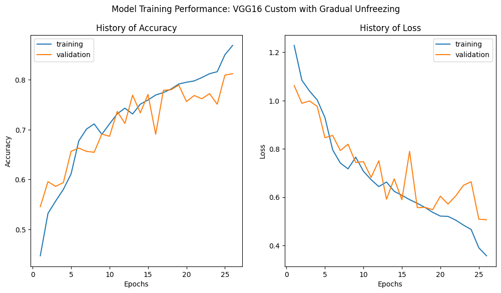

```python
training_performance_plots('VGG16 Custom with Gradual Unfreezing', overall_history_vgg)
```

```
Test accuracy: 0.84375

Classification Report:

              precision    recall  f1-score   support

       happy       0.97      0.91      0.94        32
     neutral       0.80      0.75      0.77        32
         sad       0.69      0.78      0.74        32
    surprise       0.94      0.94      0.94        32

    accuracy                           0.84       128
   macro avg       0.85      0.84      0.85       128
weighted avg       0.85      0.84      0.85       128


Confusion Matrix:
```

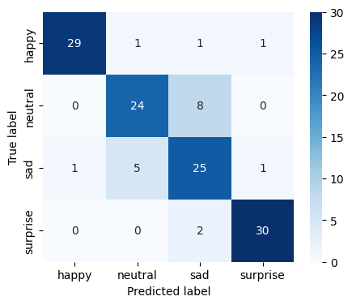

```python
predict_and_report(model_vgg16_custom, test_data)
```

**Think About It:**

- What do you infer from the general trend in the training performance?
- Is the training accuracy consistently improving?
- Is the validation accuracy also improving similarly?

**Observations and Insights:**

The custom VGG model achieved the best performance of all models tested, with an accuracy of 0.84 and f1-score of 0.85 on test data. Happy and Surprise performance is excellent - nearly 95%. Confusion persists on neutral and sad, probably reflecting poor training data labeling.

**Note: You can even go back and build your own architecture on top of the VGG16 Transfer layer and see if you can improve the performance**

## **ResNet V2 Model**

```python
backend.clear_session()
seed = 84
np.random.seed(seed)
random.seed(seed)
tf_random.set_seed(seed)
```

```python
# Increased most augmentation ranges and added brightness, v flip, and channel shift

from tensorflow.keras.preprocessing.image import ImageDataGenerator
from tensorflow.keras.applications.resnet_v2 import preprocess_input # must use the model specific preprocessing function.


taget_size = (224, 224) # Use image size on which VGG16 was originally trained, especially since we'll be training the base model layers
batch_size = 32

train_path = path + 'Facial_emotion_images/train'
validation_path = path + 'Facial_emotion_images/validation'
test_path = path + 'Facial_emotion_images/test'

# Data augmentation for training data
train_datagen = ImageDataGenerator(
    preprocessing_function=preprocess_input,
    rotation_range=5,
    width_shift_range=0.2,
    height_shift_range=0.2,
    shear_range=0.2,
    #zoom_range=0.2,
    horizontal_flip=True,
    vertical_flip=True,
    brightness_range=[0.8, 1.2],
    channel_shift_range=0.2,
    fill_mode='nearest'
)

val_datagen = ImageDataGenerator(preprocessing_function=preprocess_input)

test_datagen = ImageDataGenerator(preprocessing_function=preprocess_input)


train_data = train_datagen.flow_from_directory(
    train_path,
    target_size=taget_size,
    batch_size=batch_size,
    class_mode='categorical',
    color_mode='rgb'
)

val_data = val_datagen.flow_from_directory(
    validation_path,
    target_size=taget_size,
    batch_size=batch_size,
    class_mode='categorical',
    color_mode='rgb'
)

test_data = test_datagen.flow_from_directory(
    test_path,
    target_size=taget_size,
    batch_size=batch_size,
    class_mode='categorical',
    color_mode='rgb',
    shuffle=False
)
```

```
Found 15109 images belonging to 4 classes.
Found 4977 images belonging to 4 classes.
Found 128 images belonging to 4 classes.
```

### **Model Building**

- Import Resnet v2 upto the layer of your choice and add Fully Connected layers on top of it.

```python
from tensorflow.keras.applications import ResNet50V2

rn = ResNet50V2(include_top = False, weights = 'imagenet', input_shape = (224, 224, 3))
rn.summary()
```

```
Downloading data from https://storage.googleapis.com/tensorflow/keras-applications/resnet/resnet50v2_weights_tf_dim_ordering_tf_kernels_notop.h5
Model: "resnet50v2"
__________________________________________________________________________________________________
 Layer (type)                Output Shape                 Param #   Connected to
==================================================================================================
 input_1 (InputLayer)        [(None, 224, 224, 3)]        0         []

 conv1_pad (ZeroPadding2D)   (None, 230, 230, 3)          0         ['input_1[0][0]']

 conv1_conv (Conv2D)         (None, 112, 112, 64)         9472      ['conv1_pad[0][0]']

 pool1_pad (ZeroPadding2D)   (None, 114, 114, 64)         0         ['conv1_conv[0][0]']

 pool1_pool (MaxPooling2D)   (None, 56, 56, 64)           0         ['pool1_pad[0][0]']

 conv2_block1_preact_bn (Ba  (None, 56, 56, 64)           256       ['pool1_pool[0][0]']
 tchNormalization)

 conv2_block1_preact_relu (  (None, 56, 56, 64)           0         ['conv2_block1_preact_bn[0][0]
 Activation)                                                        ']

 conv2_block1_1_conv (Conv2  (None, 56, 56, 64)           4096      ['conv2_block1_preact_relu[0][
 D)                                                                 0]']

 conv2_block1_1_bn (BatchNo  (None, 56, 56, 64)           256       ['conv2_block1_1_conv[0][0]']
 rmalization)

 conv2_block1_1_relu (Activ  (None, 56, 56, 64)           0         ['conv2_block1_1_bn[0][0]']
 ation)

 conv2_block1_2_pad (ZeroPa  (None, 58, 58, 64)           0         ['conv2_block1_1_relu[0][0]']
 dding2D)

 conv2_block1_2_conv (Conv2  (None, 56, 56, 64)           36864     ['conv2_block1_2_pad[0][0]']
 D)

 conv2_block1_2_bn (BatchNo  (None, 56, 56, 64)           256       ['conv2_block1_2_conv[0][0]']
 rmalization)

 conv2_block1_2_relu (Activ  (None, 56, 56, 64)           0         ['conv2_block1_2_bn[0][0]']
```

[output cut: 519 more lines]

```
 D)

 conv5_block3_out (Add)      (None, 7, 7, 2048)           0         ['conv5_block2_out[0][0]',
                                                                     'conv5_block3_3_conv[0][0]']

 post_bn (BatchNormalizatio  (None, 7, 7, 2048)           8192      ['conv5_block3_out[0][0]']
 n)

 post_relu (Activation)      (None, 7, 7, 2048)           0         ['post_bn[0][0]']

==================================================================================================
Total params: 23564800 (89.89 MB)
Trainable params: 23519360 (89.72 MB)
Non-trainable params: 45440 (177.50 KB)
__________________________________________________________________________________________________
```

```python
rn.trainable = False

x = rn.get_layer('conv5_block3_out').output
x = Flatten()(x)
x = Dense(256, activation='relu', kernel_initializer='he_normal',)(x)
x = Dense(128, activation='relu', kernel_initializer='he_normal')(x)
x = Dropout(0.2)(x)
x = Dense(64, activation='relu', kernel_initializer='he_normal')(x)
x = BatchNormalization()(x)

predictions = Dense(4, activation='softmax')(x)

rn_custom = Model(inputs=rn.input, outputs=predictions)

rn_custom.summary()
```

```
Model: "model"
__________________________________________________________________________________________________
 Layer (type)                Output Shape                 Param #   Connected to
==================================================================================================
 input_1 (InputLayer)        [(None, 224, 224, 3)]        0         []

 conv1_pad (ZeroPadding2D)   (None, 230, 230, 3)          0         ['input_1[0][0]']

 conv1_conv (Conv2D)         (None, 112, 112, 64)         9472      ['conv1_pad[0][0]']

 pool1_pad (ZeroPadding2D)   (None, 114, 114, 64)         0         ['conv1_conv[0][0]']

 pool1_pool (MaxPooling2D)   (None, 56, 56, 64)           0         ['pool1_pad[0][0]']

 conv2_block1_preact_bn (Ba  (None, 56, 56, 64)           256       ['pool1_pool[0][0]']
 tchNormalization)

 conv2_block1_preact_relu (  (None, 56, 56, 64)           0         ['conv2_block1_preact_bn[0][0]
 Activation)                                                        ']

 conv2_block1_1_conv (Conv2  (None, 56, 56, 64)           4096      ['conv2_block1_preact_relu[0][
 D)                                                                 0]']

 conv2_block1_1_bn (BatchNo  (None, 56, 56, 64)           256       ['conv2_block1_1_conv[0][0]']
 rmalization)

 conv2_block1_1_relu (Activ  (None, 56, 56, 64)           0         ['conv2_block1_1_bn[0][0]']
 ation)

 conv2_block1_2_pad (ZeroPa  (None, 58, 58, 64)           0         ['conv2_block1_1_relu[0][0]']
 dding2D)

 conv2_block1_2_conv (Conv2  (None, 56, 56, 64)           36864     ['conv2_block1_2_pad[0][0]']
 D)

 conv2_block1_2_bn (BatchNo  (None, 56, 56, 64)           256       ['conv2_block1_2_conv[0][0]']
 rmalization)

 conv2_block1_2_relu (Activ  (None, 56, 56, 64)           0         ['conv2_block1_2_bn[0][0]']
 ation)
```

[output cut: 529 more lines]

```

 dropout (Dropout)           (None, 128)                  0         ['dense_1[0][0]']

 dense_2 (Dense)             (None, 64)                   8256      ['dropout[0][0]']

 batch_normalization (Batch  (None, 64)                   256       ['dense_2[0][0]']
 Normalization)

 dense_3 (Dense)             (None, 4)                    260       ['batch_normalization[0][0]']

==================================================================================================
Total params: 49288644 (188.02 MB)
Trainable params: 25731908 (98.16 MB)
Non-trainable params: 23556736 (89.86 MB)
__________________________________________________________________________________________________
```

### **Compiling and Training the Model**

```python
rn_custom.compile(optimizer=AdamW(learning_rate=0.00001),
                           loss='categorical_crossentropy',
                           metrics=['accuracy'])


checkpoint = ModelCheckpoint("rn_custom.h5",
                             monitor='val_acc',
                             mode='max',
                             save_best_only=True,
                             verbose=1)

earlystop = EarlyStopping(monitor='val_loss',
                          min_delta=0,
                          patience=4,
                          verbose=1,
                          restore_best_weights=True)

reduce_lr = ReduceLROnPlateau(monitor='val_loss',
                              factor=0.2,
                              patience=3,
                              verbose=1,
                              min_delta=0.00001)

callbacks = [checkpoint, earlystop, reduce_lr]
```

```python
# Implement training with gradual unfreezing of layers on the base model, 1 block at a time:

epochs = 4

overall_history_rn = {
    'accuracy': [],
    'loss': [],
    'val_accuracy': [],
    'val_loss': []
}

## Training Block 1 ##
history_rn = rn_custom.fit(
    train_data,
    epochs=epochs,
    validation_data=val_data,
    callbacks=callbacks
)

for key in overall_history_rn.keys():
    overall_history_rn[key].extend(history_rn.history[key])


## Training Block 2 ##

# Unlock Layers and Recompile Model:
for layer in rn.layers[-4:]:
    layer.trainable=True

rn_custom.compile(optimizer=AdamW(learning_rate=0.0001),
                           loss='categorical_crossentropy',
                           metrics=['accuracy'])

history_rn = rn_custom.fit(
    train_data,
    epochs=epochs,
    validation_data=val_data,
    callbacks=callbacks
)

for key in overall_history_rn.keys():
    overall_history_rn[key].extend(history_rn.history[key])


## Training Block 3 ##

# Unlock Layers and Recompile Model:
for layer in rn.layers[-8:]:
    layer.trainable=True

rn_custom.compile(optimizer=AdamW(learning_rate=0.0001),
                           loss='categorical_crossentropy',
                           metrics=['accuracy'])

history_rn = rn_custom.fit(
    train_data,
    epochs=epochs,
    validation_data=val_data,
    callbacks=callbacks
)

for key in overall_history_rn.keys():
    overall_history_rn[key].extend(history_rn.history[key])


## Training Block 4 ##

# Unlock Layers and Recompile Model:
for layer in rn.layers[-12:]:
    layer.trainable=True

rn_custom.compile(optimizer=AdamW(learning_rate=0.0001),
                           loss='categorical_crossentropy',
                           metrics=['accuracy'])

history_rn = rn_custom.fit(
    train_data,
    epochs=epochs,
    validation_data=val_data,
    callbacks=callbacks
)

for key in overall_history_rn.keys():
    overall_history_rn[key].extend(history_rn.history[key])


## Training Block 5 ##

# Unlock Layers and Recompile Model:
for layer in rn.layers[-12:]:
    layer.trainable=True

rn_custom.compile(optimizer=AdamW(learning_rate=0.0001),
                           loss='categorical_crossentropy',
                           metrics=['accuracy'])

history_rn = rn_custom.fit(
    train_data,
    epochs=epochs,
    validation_data=val_data,
    callbacks=callbacks
)

for key in overall_history_rn.keys():
    overall_history_rn[key].extend(history_rn.history[key])


## Training Block 6 ##

# Unlock Layers and Recompile Model:
for layer in rn.layers[-15:]:
    layer.trainable=True

rn_custom.compile(optimizer=Adam(learning_rate=0.00005),
                           loss='categorical_crossentropy',
                           metrics=['accuracy'])

history_rn = rn_custom.fit(
    train_data,
    epochs=8,
    validation_data=val_data,
    callbacks=callbacks
)

for key in overall_history_rn.keys():
    overall_history_rn[key].extend(history_rn.history[key])


## Training Block 7 ##

# Unlock Layers and Recompile Model:
for layer in rn.layers[:]:
    layer.trainable=True

rn_custom.compile(optimizer=Adam(learning_rate=0.00001), # when using 0.0001, model began overfitting in this block, but prob better ways to mitigate overfitting if a big problem
                           loss='categorical_crossentropy',
                           metrics=['accuracy'])

history_rn = rn_custom.fit(
    train_data,
    epochs=epochs,
    validation_data=val_data,
    callbacks=callbacks
)
```

[output not shown]

[output not shown]

[output not shown]

[output not shown]

[output not shown]

[output not shown]

[output not shown]

[output not shown]

[output not shown]

[output not shown]

[output not shown]

[output not shown]

[output not shown]

[output not shown]

[output not shown]

[output not shown]

[output not shown]

[output not shown]

[output not shown]

[output not shown]

```
Epoch 4: ReduceLROnPlateau reducing learning rate to 1.9999999494757503e-05.
```

[output not shown]

[output not shown]

[output not shown]

[output not shown]

[output not shown]

[output not shown]

[output not shown]

[output not shown]

```
Epoch 8: ReduceLROnPlateau reducing learning rate to 9.999999747378752e-06.
```

[output not shown]

[output not shown]

[output not shown]

[output not shown]

### **Evaluating the ResNet Model**

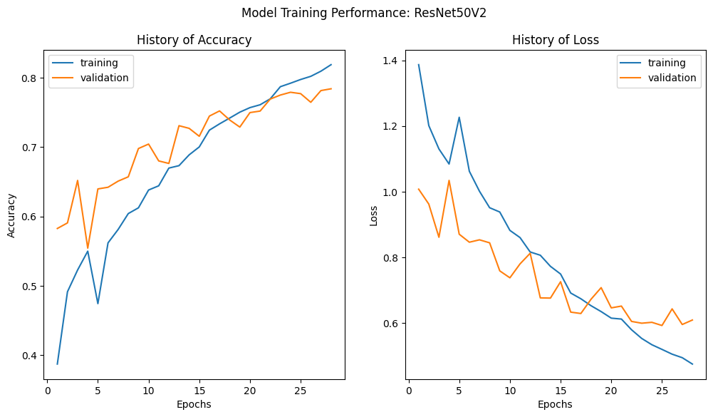

```python
training_performance_plots('ResNet50V2', overall_history_rn)
```

```python
predict_and_report(rn_custom, test_data_rgb)
```

[output not shown]

[output cut: 69 more lines]

[output not shown]

**Observations and Insights:**

ResNet was successfully trained to val_accuracy: 0.7693 but was unable to evaluate test data. It seems there's a matrix multiplication error somewhere but I was not able to resolve.

## **EfficientNet Model**

```python
backend.clear_session()
seed = 3
np.random.seed(seed)
random.seed(seed)
tf_random.set_seed(seed)
```

```python
# Increased most augmentation ranges and added brightness, v flip, and channel shift

from tensorflow.keras.preprocessing.image import ImageDataGenerator
from tensorflow.keras.applications.efficientnet import preprocess_input # must use the model specific preprocessing function.


taget_size = (224, 224) # Use image size on which VGG16 was originally trained, especially since we'll be training the base model layers
batch_size = 32

train_path = path + 'Facial_emotion_images/train'
validation_path = path + 'Facial_emotion_images/validation'
test_path = path + 'Facial_emotion_images/test'

# Data augmentation for training data
train_datagen = ImageDataGenerator(
    preprocessing_function=preprocess_input,
    rotation_range=5,
    width_shift_range=0.2,
    height_shift_range=0.2,
    shear_range=0.2,
    #zoom_range=0.2,
    horizontal_flip=True,
    vertical_flip=True,
    brightness_range=[0.8, 1.2],
    channel_shift_range=0.2,
    fill_mode='nearest'
)

val_datagen = ImageDataGenerator(preprocessing_function=preprocess_input)

test_datagen = ImageDataGenerator(preprocessing_function=preprocess_input)


train_data = train_datagen.flow_from_directory(
    train_path,
    target_size=taget_size,
    batch_size=batch_size,
    class_mode='categorical',
    color_mode='rgb'
)

val_data = val_datagen.flow_from_directory(
    validation_path,
    target_size=taget_size,
    batch_size=batch_size,
    class_mode='categorical',
    color_mode='rgb'
)

test_data = test_datagen.flow_from_directory(
    test_path,
    target_size=taget_size,
    batch_size=batch_size,
    class_mode='categorical',
    color_mode='rgb',
    shuffle=False
)
```

```
Found 15109 images belonging to 4 classes.
Found 4977 images belonging to 4 classes.
Found 128 images belonging to 4 classes.
```

```python
import tensorflow.keras.applications as ap
from tensorflow.keras import Model

EfficientNet = ap.EfficientNetV2B2(include_top=False, weights="imagenet", input_shape= (224, 224, 3))

EfficientNet.summary()
```

```
Model: "efficientnetv2-b2"
__________________________________________________________________________________________________
 Layer (type)                Output Shape                 Param #   Connected to
==================================================================================================
 input_1 (InputLayer)        [(None, 224, 224, 3)]        0         []

 rescaling (Rescaling)       (None, 224, 224, 3)          0         ['input_1[0][0]']

 normalization (Normalizati  (None, 224, 224, 3)          0         ['rescaling[0][0]']
 on)

 stem_conv (Conv2D)          (None, 112, 112, 32)         864       ['normalization[0][0]']

 stem_bn (BatchNormalizatio  (None, 112, 112, 32)         128       ['stem_conv[0][0]']
 n)

 stem_activation (Activatio  (None, 112, 112, 32)         0         ['stem_bn[0][0]']
 n)

 block1a_project_conv (Conv  (None, 112, 112, 16)         4608      ['stem_activation[0][0]']
 2D)

 block1a_project_bn (BatchN  (None, 112, 112, 16)         64        ['block1a_project_conv[0][0]']
 ormalization)

 block1a_project_activation  (None, 112, 112, 16)         0         ['block1a_project_bn[0][0]']
  (Activation)

 block1b_project_conv (Conv  (None, 112, 112, 16)         2304      ['block1a_project_activation[0
 2D)                                                                ][0]']

 block1b_project_bn (BatchN  (None, 112, 112, 16)         64        ['block1b_project_conv[0][0]']
 ormalization)

 block1b_project_activation  (None, 112, 112, 16)         0         ['block1b_project_bn[0][0]']
  (Activation)

 block1b_drop (Dropout)      (None, 112, 112, 16)         0         ['block1b_project_activation[0
                                                                    ][0]']

```

[output cut: 937 more lines]

```
                                                                     'block6i_add[0][0]']

 top_conv (Conv2D)           (None, 7, 7, 1408)           292864    ['block6j_add[0][0]']

 top_bn (BatchNormalization  (None, 7, 7, 1408)           5632      ['top_conv[0][0]']
 )

 top_activation (Activation  (None, 7, 7, 1408)           0         ['top_bn[0][0]']
 )

==================================================================================================
Total params: 8769374 (33.45 MB)
Trainable params: 8687086 (33.14 MB)
Non-trainable params: 82288 (321.44 KB)
__________________________________________________________________________________________________
```

### **Model Building**

- Import EfficientNet upto the layer of your choice and add Fully Connected layers on top of it.

```python
EfficientNet.trainable = False

base_model = EfficientNetB0(include_top=False, weights='imagenet', input_shape=(224, 224, 3))
model_output = base_model.get_layer('block6e_expand_activation').output

x = Flatten()(model_output)
x = Dense(512, activation='relu')(x)
x = BatchNormalization()(x)
x = Dropout(0.5)(x)
x = Dense(128, activation='relu')(x)
x = BatchNormalization()(x)
x = Dropout(0.5)(x)
predictions = Dense(4, activation='softmax')(x)

model = Model(inputs=base_model.input, outputs=predictions)
```

```python
print(EfficientNet.get_layer('block6e_expand_activation').output_shape)
```

```
(None, 7, 7, 1248)
```

```python
print(efficient_custom.get_layer('block6e_expand_activation').output_shape)
```

```python
EfficientNet.trainable = False

x = EfficientNet.get_layer('block6e_expand_activation').output

x = Flatten()(x)
x = Dense(512, activation='relu')(x)
x = BatchNormalization()(x)
x = Dropout(0.3)(x)
x = Dense(128, activation='relu')(x)
x = BatchNormalization()(x)
x = Dropout(0.3)(x)
predictions = Dense(4, activation='softmax')(x)

efficient_custom = Model(inputs=EfficientNet.input, outputs=predictions)

efficient_custom.summary()
```

```
Model: "model"
__________________________________________________________________________________________________
 Layer (type)                Output Shape                 Param #   Connected to
==================================================================================================
 input_1 (InputLayer)        [(None, 224, 224, 3)]        0         []

 rescaling (Rescaling)       (None, 224, 224, 3)          0         ['input_1[0][0]']

 normalization (Normalizati  (None, 224, 224, 3)          0         ['rescaling[0][0]']
 on)

 stem_conv (Conv2D)          (None, 112, 112, 32)         864       ['normalization[0][0]']

 stem_bn (BatchNormalizatio  (None, 112, 112, 32)         128       ['stem_conv[0][0]']
 n)

 stem_activation (Activatio  (None, 112, 112, 32)         0         ['stem_bn[0][0]']
 n)

 block1a_project_conv (Conv  (None, 112, 112, 16)         4608      ['stem_activation[0][0]']
 2D)

 block1a_project_bn (BatchN  (None, 112, 112, 16)         64        ['block1a_project_conv[0][0]']
 ormalization)

 block1a_project_activation  (None, 112, 112, 16)         0         ['block1a_project_bn[0][0]']
  (Activation)

 block1b_project_conv (Conv  (None, 112, 112, 16)         2304      ['block1a_project_activation[0
 2D)                                                                ][0]']

 block1b_project_bn (BatchN  (None, 112, 112, 16)         64        ['block1b_project_conv[0][0]']
 ormalization)

 block1b_project_activation  (None, 112, 112, 16)         0         ['block1b_project_bn[0][0]']
  (Activation)

 block1b_drop (Dropout)      (None, 112, 112, 16)         0         ['block1b_project_activation[0
                                                                    ][0]']

```

[output cut: 707 more lines]

```
 dense_1 (Dense)             (None, 128)                  65664     ['dropout[0][0]']

 batch_normalization_1 (Bat  (None, 128)                  512       ['dense_1[0][0]']
 chNormalization)

 dropout_1 (Dropout)         (None, 128)                  0         ['batch_normalization_1[0][0]'
                                                                    ]

 dense_2 (Dense)             (None, 4)                    516       ['dropout_1[0][0]']

==================================================================================================
Total params: 36080682 (137.64 MB)
Trainable params: 31377796 (119.70 MB)
Non-trainable params: 4702886 (17.94 MB)
__________________________________________________________________________________________________
```

### **Compiling and Training the Model**

```python
efficient_custom.compile(optimizer=AdamW(learning_rate=0.00001),
                           loss='categorical_crossentropy',
                           metrics=['accuracy'])


checkpoint = ModelCheckpoint("efficient_custom.h5",
                             monitor='val_acc',
                             mode='max',
                             save_best_only=True,
                             verbose=1)

earlystop = EarlyStopping(monitor='val_loss',
                          min_delta=0,
                          patience=4,
                          verbose=1,
                          restore_best_weights=True)

reduce_lr = ReduceLROnPlateau(monitor='val_loss',
                              factor=0.2,
                              patience=3,
                              verbose=1,
                              min_delta=0.00001)

callbacks = [checkpoint, earlystop, reduce_lr]
```

```python
history_en = efficient_custom.fit(
    train_data_rgb,
    steps_per_epoch=train_data_rgb.samples // batch_size,
    epochs=20,
    validation_data=validation_data_rgb,
    validation_steps=validation_data_rgb.samples // batch_size,
    callbacks=callbacks
)
```

[output not shown]

[output cut: 64 more lines]

[output not shown]

### **Evaluating the EfficientnetNet Model**

**Observations and Insights:**

My EfficientNet model crashed and burned. I was unable to troubleshoot the issue. It seems there's a mismatch in one or more input/output shape compatibilitiy given the "Matrix size-incompatible" error but I couldn't figure out how to correct it.

**Note: You can even go back and build your own architecture on top of the VGG16 Transfer layer and see if you can improve the performance.**

**Think About It:**

- What is your overall performance of these Transfer Learning Architectures? Can we draw a comparison of these models' performances. Are we satisfied with the accuracies that we have received?
- Do you think our issue lies with 'rgb' color_mode?

Now that we have tried multiple pre-trained models, let's build a complex CNN architecture and see if we can get better performance.

## **Creating our Data Loaders**

In this section, we are creating data loaders which we will use as inputs to the more Complicated Convolutional Neural Network. We will go ahead with color_mode = 'grayscale'.

```python
backend.clear_session()
seed = 25
np.random.seed(seed)
random.seed(seed)
tf_random.set_seed(seed)
```

### **Model Building**

- Try building a layer with 5 Convolutional Blocks and see if performance increases.

```python
input_shape = (48, 48, 1)
inputs = Input(shape=input_shape)

x = Conv2D(64, kernel_size=2, padding='same', activation='relu')(inputs)
x = BatchNormalization()(x)
x = LeakyReLU(alpha=0.1)(x)
x = MaxPooling2D(pool_size=2)(x)
x = Dropout(0.2)(x)

x = Conv2D(128, kernel_size=2, padding='same', activation='relu')(x)
x = BatchNormalization()(x)
x = LeakyReLU(alpha=0.1)(x)
x = MaxPooling2D(pool_size=2)(x)
x = Dropout(0.2)(x)

x = Conv2D(512, kernel_size=2, padding='same', activation='relu')(x)
x = BatchNormalization()(x)
x = LeakyReLU(alpha=0.1)(x)
x = MaxPooling2D(pool_size=2)(x)
x = Dropout(0.2)(x)

x = Conv2D(512, kernel_size=2, padding='same', activation='relu')(x)
x = BatchNormalization()(x)
x = LeakyReLU(alpha=0.1)(x)
x = MaxPooling2D(pool_size=2)(x)
x = Dropout(0.2)(x)

x = Conv2D(128, kernel_size=2, padding='same', activation='relu')(x)
x = BatchNormalization()(x)
x = LeakyReLU(alpha=0.1)(x)
x = MaxPooling2D(pool_size=2)(x)
x = Dropout(0.2)(x)

x = Flatten()(x)
x = Dense(256)(x)
x = BatchNormalization()(x)
x = LeakyReLU(alpha=0.1)(x)
x = Dropout(0.5)(x)

x = Dense(512)(x)
x = BatchNormalization()(x)
x = LeakyReLU(alpha=0.1)(x)
x = Dropout(0.5)(x)

predictions = Dense(4, activation='softmax')(x)

model_cnn3 = Model(inputs=inputs, outputs=predictions)

model_cnn3.summary()
```

```
Model: "model_1"
_________________________________________________________________
 Layer (type)                Output Shape              Param #
=================================================================
 input_2 (InputLayer)        [(None, 48, 48, 1)]       0

 conv2d_5 (Conv2D)           (None, 48, 48, 64)        320

 batch_normalization_7 (Bat  (None, 48, 48, 64)        256
 chNormalization)

 leaky_re_lu_7 (LeakyReLU)   (None, 48, 48, 64)        0

 max_pooling2d_5 (MaxPoolin  (None, 24, 24, 64)        0
 g2D)

 dropout_7 (Dropout)         (None, 24, 24, 64)        0

 conv2d_6 (Conv2D)           (None, 24, 24, 128)       32896

 batch_normalization_8 (Bat  (None, 24, 24, 128)       512
 chNormalization)

 leaky_re_lu_8 (LeakyReLU)   (None, 24, 24, 128)       0

 max_pooling2d_6 (MaxPoolin  (None, 12, 12, 128)       0
 g2D)

 dropout_8 (Dropout)         (None, 12, 12, 128)       0

 conv2d_7 (Conv2D)           (None, 12, 12, 512)       262656

 batch_normalization_9 (Bat  (None, 12, 12, 512)       2048
 chNormalization)

 leaky_re_lu_9 (LeakyReLU)   (None, 12, 12, 512)       0

 max_pooling2d_7 (MaxPoolin  (None, 6, 6, 512)         0
 g2D)

```

[output cut: 38 more lines]

```

 batch_normalization_13 (Ba  (None, 512)               2048
 tchNormalization)

 leaky_re_lu_13 (LeakyReLU)  (None, 512)               0

 dropout_13 (Dropout)        (None, 512)               0

 dense_5 (Dense)             (None, 4)                 2052

=================================================================
Total params: 1782340 (6.80 MB)
Trainable params: 1778116 (6.78 MB)
Non-trainable params: 4224 (16.50 KB)
_________________________________________________________________
```

### **Compiling and Training the Model**

```python
learning_rate=0.001 # default is 0.001

custom_optimizer = Adam(learning_rate=learning_rate)

model_cnn3.compile(optimizer=custom_optimizer,
                   loss='categorical_crossentropy',
                   metrics=['accuracy'])

checkpoint = ModelCheckpoint("model_EfficientNet_custom.h5",
                             monitor='val_acc',
                             mode='max',
                             save_best_only=True,
                             verbose=1)

earlystop = EarlyStopping(monitor='val_loss',
                          min_delta=0,
                          patience=5,
                          verbose=1,
                          restore_best_weights=True)

reduce_lr = ReduceLROnPlateau(monitor='val_loss',
                              factor=0.2,
                              patience=4,
                              verbose=1,
                              min_delta=0.00001)

callbacks = [checkpoint, earlystop, reduce_lr]
```

### **Evaluating the Model on Test Set**

```python
batch_size = 32

history_cnn3 = model_cnn3.fit(
    train_data_g,
    steps_per_epoch=train_data_g.samples // batch_size,
    epochs=50,
    validation_data=validation_data_g,
    validation_steps=validation_data_g.samples // batch_size,
    callbacks=callbacks
)
```

[output not shown]

[output not shown]

[output not shown]

[output not shown]

[output not shown]

[output not shown]

[output not shown]

[output not shown]

[output not shown]

[output not shown]

[output not shown]

[output not shown]

[output not shown]

[output not shown]

[output not shown]

[output not shown]

[output not shown]

[output not shown]

[output not shown]

```
Epoch 19: ReduceLROnPlateau reducing learning rate to 0.00020000000949949026.
```

[output not shown]

[output not shown]

[output not shown]

[output not shown]

[output not shown]

[output not shown]

[output not shown]

[output not shown]

```
Epoch 27: ReduceLROnPlateau reducing learning rate to 4.0000001899898055e-05.
```

[output not shown]

```
Restoring model weights from the end of the best epoch: 23.
Epoch 28: early stopping
```

```python
model_path1 = "/content/drive/MyDrive/MIT-ADSP/7-Capstone/model_cnn3.h5"
model_path2 = "/content/drive/MyDrive/MIT-ADSP/7-Capstone/model_cnn3.keras"
model_cnn3.save(model_path1)
model_cnn3.save(model_path2)
```

**Observations and Insights:__**

default learning: accuracy = 0.6825

### **Plotting the Confusion Matrix for the chosen final model**

```
Test accuracy: 0.765625
              precision    recall  f1-score   support

       happy       0.81      0.91      0.85        32
     neutral       0.67      0.62      0.65        32
         sad       0.66      0.66      0.66        32
    surprise       0.93      0.88      0.90        32

    accuracy                           0.77       128
   macro avg       0.77      0.77      0.76       128
weighted avg       0.77      0.77      0.76       128
```

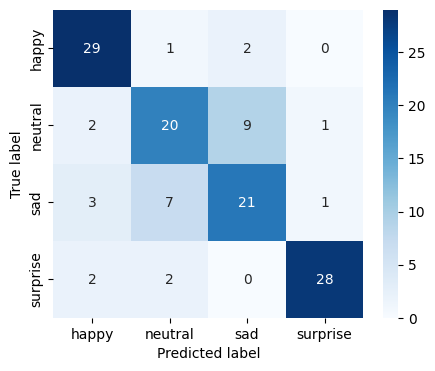

```python
predict = model_cnn3.predict(test_data_g, steps=test_data_g.samples/test_data_g.batch_size)

predict_labels = np.argmax(predict, axis = 1)

y_test = test_data_g.classes

accuracy = np.sum(predict_labels == y_test) / len(y_test)
print(f"Test accuracy: {accuracy}")

report = classification_report(y_test, predict_labels, target_names=test_data_g.class_indices.keys())

print(report)

cm = confusion_matrix(y_test, predict_labels)

plt.figure(figsize=(5, 4))
sns.heatmap(cm, annot=True, fmt='d', cmap='Blues',
            xticklabels=test_data_g.class_indices,
            yticklabels=test_data_g.class_indices)
plt.ylabel('True label')
plt.xlabel('Predicted label')
plt.show()
```

**Observations and Insights:**

## **Conclusion:**

### **Refined insights**:

- Many of images are hard to classify "correctly" by the human eye, so perhaps the quality of the dataset defines a ceiling for performance is below 0.9. After succeeding with the VGG model, we see almost 95% f1-score with happy and surprise but confusion persists with neutral and sad.

### **Proposal for the final solution design**:

- Adopt the custom VGG model.
- Consider troubleshooting and fixing the resnet model.